# TP1 - Correction

Applications sur données réelles - ADULT

## Analyses univariées

### Variable cible `class`

On remarque qu’il y a 75% des interrogés qui gagnent moins de 50000$ par an. Il n’y a clairement pas équirépartition entre les deux groupes (*p-value* = < 2.22e-16 – donc largement inférieure à 5%).

| Modalité | Nb de personnes | % du total |
| --- | --- | --- |
| <=50K | 24720 | 75.92 |
| >50K | 7841 | 24.08 |

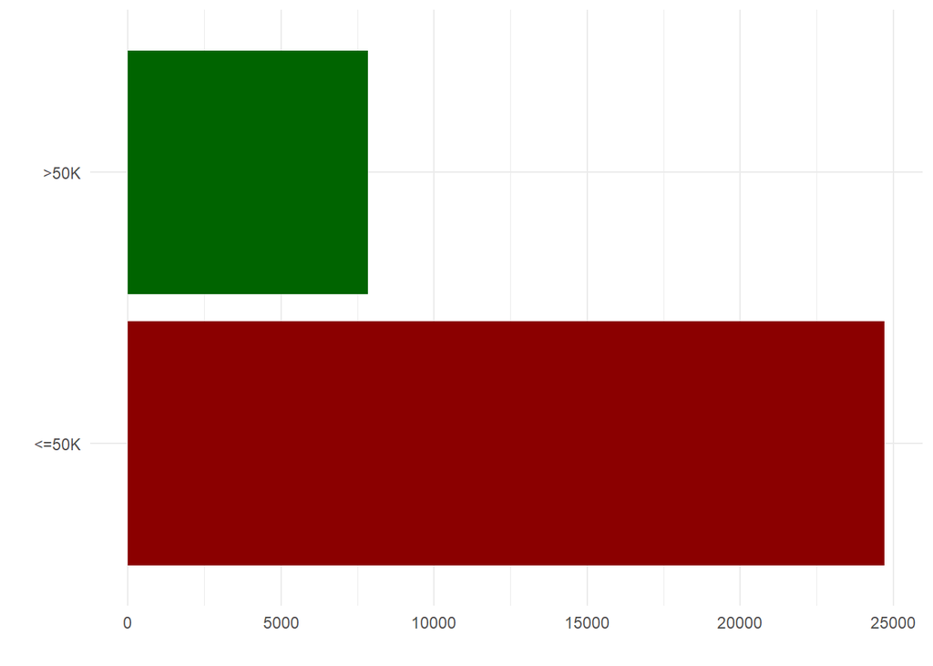

### Variable `age`

| Statistique | Valeur |
| --- | --- |
| Min. | 17.00 |
| 1st Qu. | 28.00 |
| Median | 37.00 |
| Mean | 38.58 |
| 3rd Qu. | 48.00 |
| Max. | 90.00 |
| Variance | 186.06 |
| Ecart-type | 13.64 |

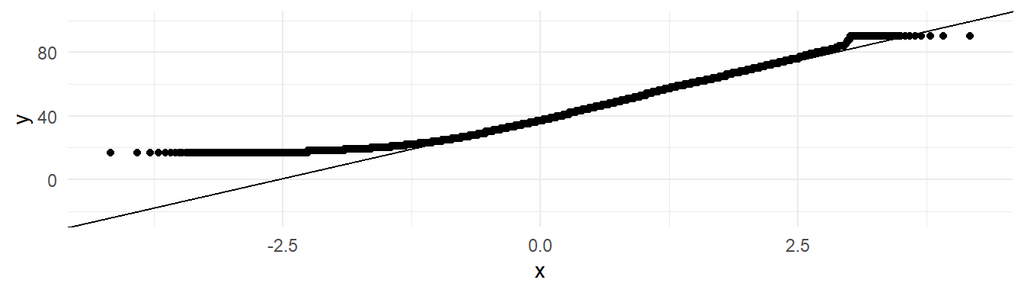

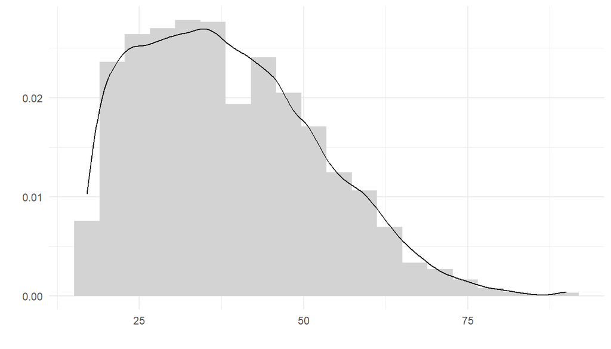

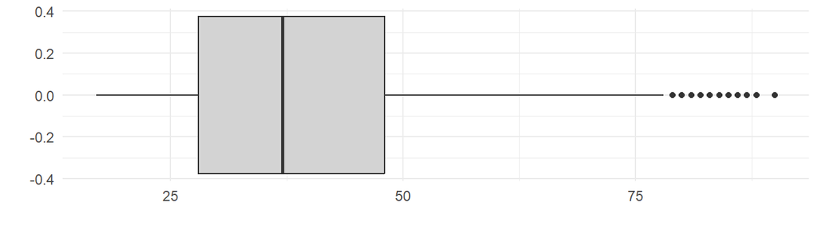

### Variable `hours_per_week`

Le temps de travail semble être de 40 heures légalement. Pour autant, un certain nombre de personnes travaillent plus (voire beaucoup plus – jusque presque 100 heures par semaine), et d’autres assez peu (1 heure au minimum). La variable ne suit pas du tout une loi normale.

| Statistique | Valeur |
| --- | --- |
| Min. | 1.00 |
| 1st Qu. | 40.00 |
| Median | 40.00 |
| Mean | 40.44 |
| 3rd Qu. | 45.00 |
| Max. | 99.00 |
| Variance | 152.46 |
| Ecart-type | 12.35 |

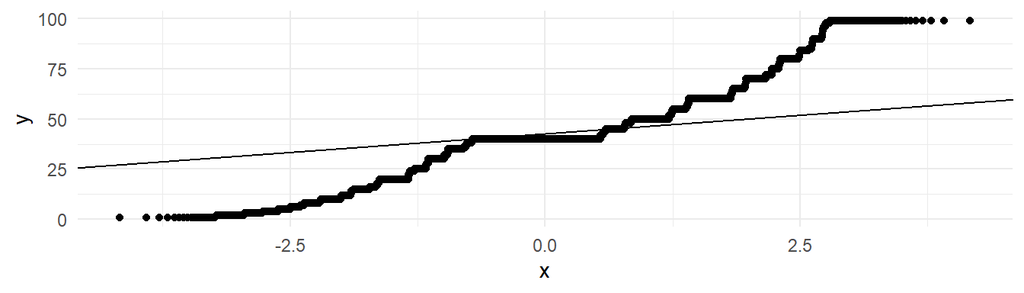

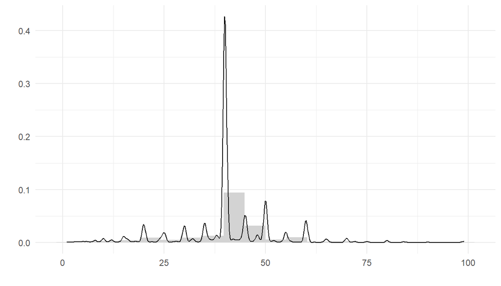

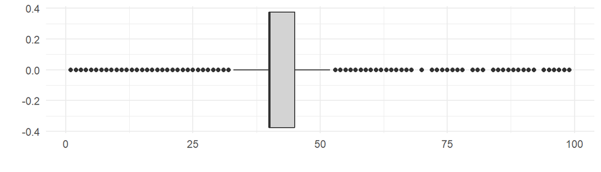

### Variables `capital_gain` et `capital_loss`

Beaucoup d’individus ont la valeur 0 pour ces deux variables. Elles ne suivent clairement pas une loi normale, et on peut envisager de les transformer en variable binaire :

- 0 (`FALSE`) = les deux variables ont la valeur 0
- 1 (`TRUE`) = une des deux variables est différente de 0

#### `capital_gain`

| Statistique | Valeur |
| --- | --- |
| Min. | 0.00 |
| 1st Qu. | 0.00 |
| Median | 0.00 |
| Mean | 1077.65 |
| 3rd Qu. | 0.00 |
| Max. | 99999.00 |
| Variance | 54542539.18 |
| Ecart-type | 7385.29 |

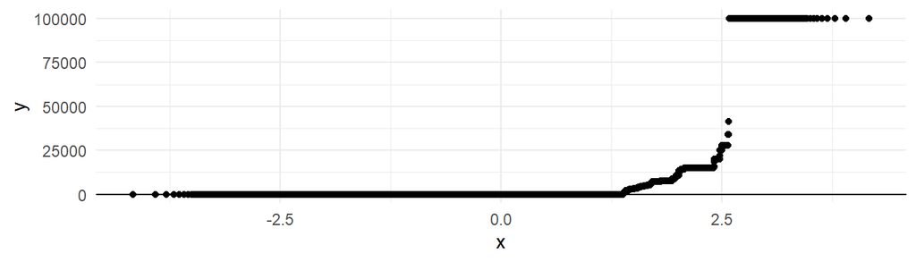

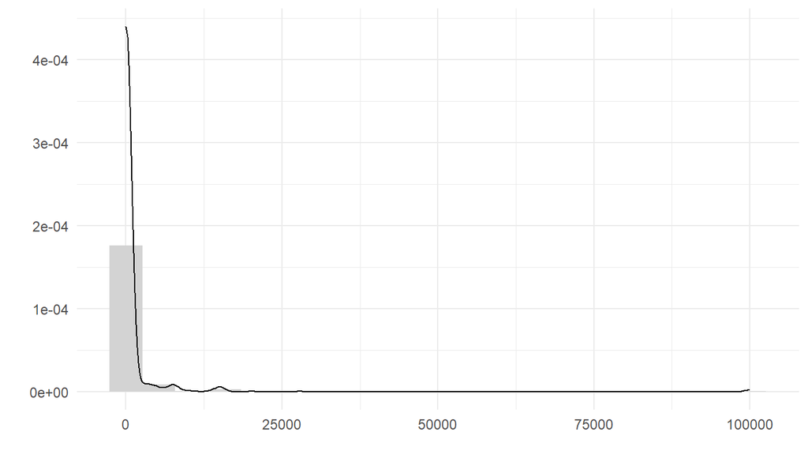

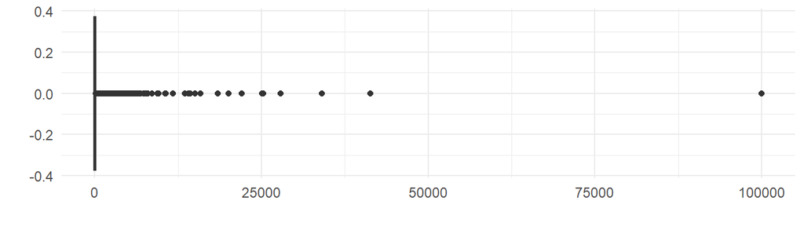

#### `capital_loss`

| Statistique | Valeur |
| --- | --- |
| Min. | 0.00 |
| 1st Qu. | 0.00 |
| Median | 0.00 |
| Mean | 87.30 |
| 3rd Qu. | 0.00 |
| Max. | 4356.00 |
| Variance | 162376.94 |
| Ecart-type | 402.96 |

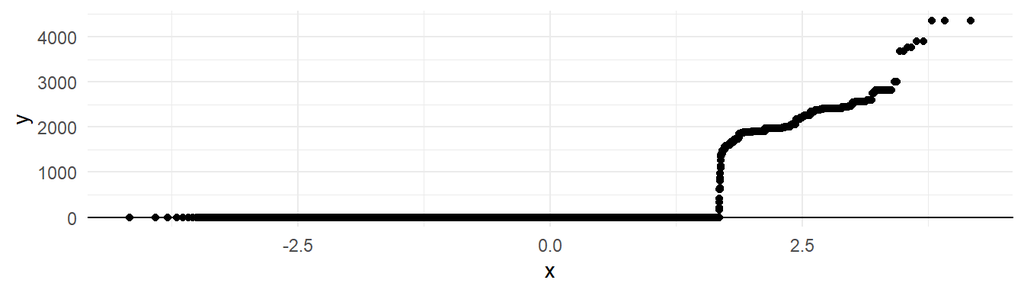

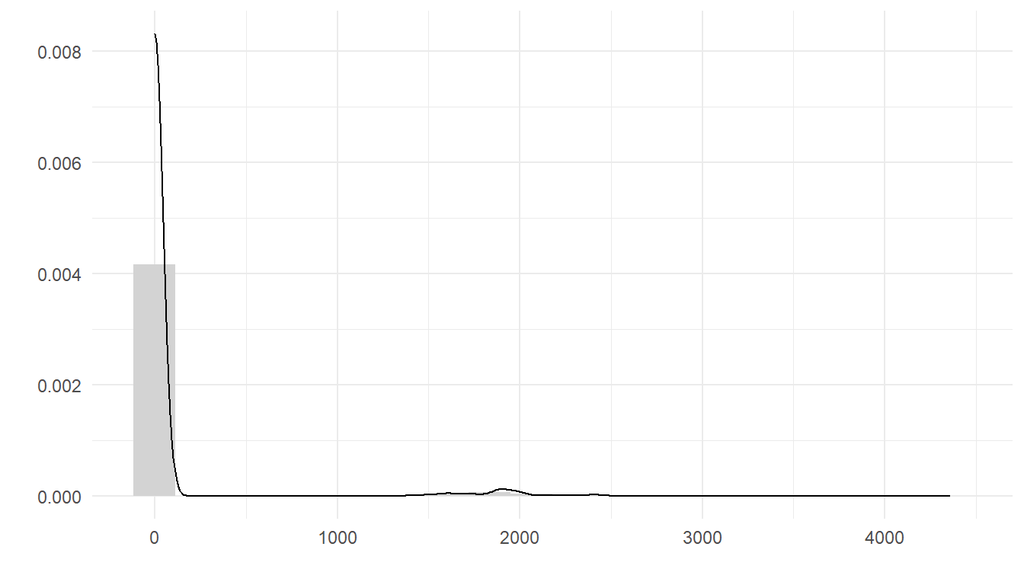

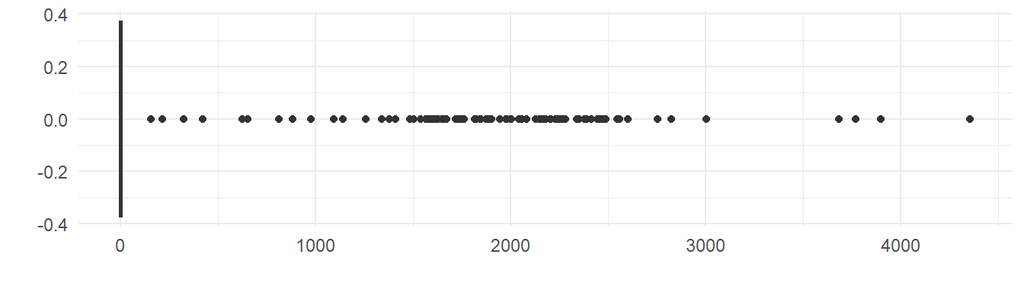

#### Tranformation en variable binaire

On vérifie déjà qu’il n’y a bien aucun individu avec des valeurs supérieurs à 0 dans les deux variables.

```
## [1] 0
```

Dans ce cas, il est possible de penser à trois transformations possibles :

- *Binariser* ces deux variables, en mettant la valeur 1 si c’est supérieur à 0 et 0 sinon
- Créer une seule nouvelle variable à trois valeurs possible : *Perte*, *Rien*, *Gain*
- Créer deux variables *imbriquées* :
  - On peut considérer que s’il y a perte ou gain de capital, c’est qu’il y a investissement. Au contraire, s’il n’y a rien, c’est que très sûrement, il n’y a pas d’investissement
  - La première variable indiquera s’il y a investissement
  - La deuxième variable, qui n’aura de valeur que pour les individus ayant un investissement, sera égale à *Perte* ou *Gain*.

Voici les codes pour chaque possibilité, ainsi qu’un graphique descriptif des nouvelles variables

##### Binarisation des variables

Assez peu de valeurs à `TRUE`

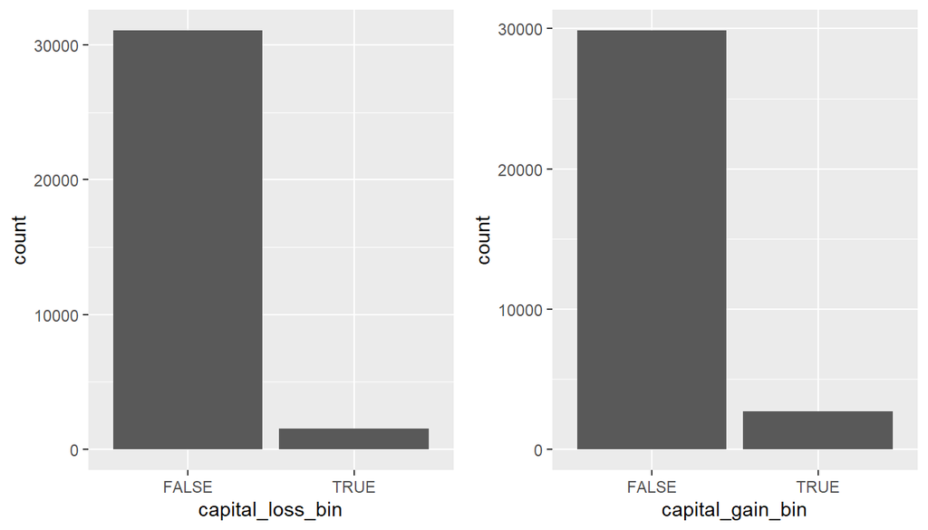

```r
adult_transform1 = adult %>%
  mutate(capital_loss_bin = capital_loss > 0,
         capital_gain_bin = capital_gain > 0)

g1 = ggplot(adult_transform1, aes(capital_loss_bin)) +
  geom_bar()
g2 = ggplot(adult_transform1, aes(capital_gain_bin)) +
  geom_bar()
grid.arrange(g1, g2, ncol = 2)
```

##### Création d’une seule variable à trois modalités

Beaucoup de *Rien* et peu de *Perte* ou de *Gain*

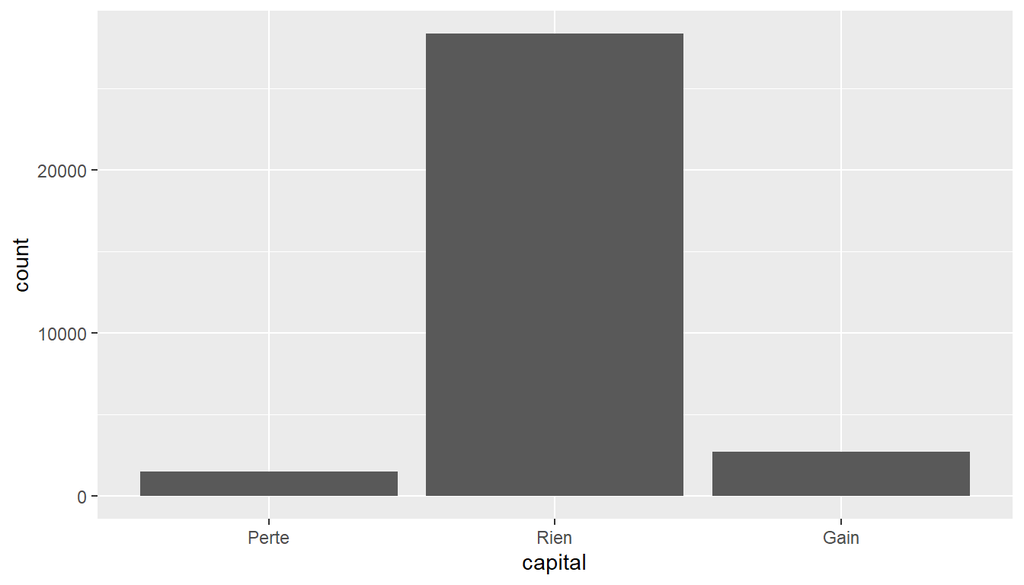

```r
adult_transform2 = adult %>%
  mutate(capital = capital_gain - capital_loss) %>%
  mutate(capital = ifelse(capital < 0,
                          "Perte",
                          ifelse(capital > 0,
                                 "Gain",
                                 "Rien")))

ggplot(adult_transform2, aes(capital)) +
  geom_bar() +
  scale_x_discrete(limits = c("Perte", "Rien", "Gain"))
```

##### Création de deux variables imbriquées

Peu d’investissement donc, mais plus de gain que de perte.

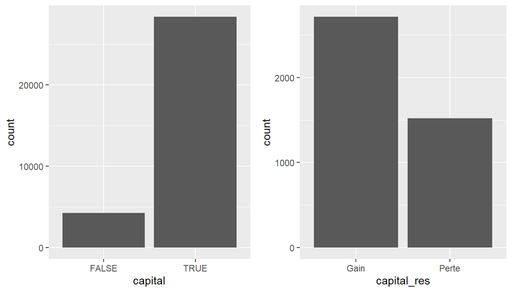

```r
adult_transform3 = adult %>%
  mutate(capital = capital_gain + capital_loss == 0) %>%
  mutate(capital_res = ifelse(capital_gain > 0,
                              "Gain",
                              ifelse(capital_loss > 0,
                                     "Perte",
                                     NA)))

g1 = ggplot(adult_transform3, aes(capital)) +
  geom_bar()
# drop_na() permet de supprimer les lignes avec données manquantes
g2 = ggplot(adult_transform3 %>% drop_na(),
            aes(capital_res)) +
  geom_bar()
grid.arrange(g1, g2, ncol = 2)
```

### Variable `sex`

Il y a deux fois plus d’hommes que de femmes dans l’échantillon. Il n’y a clairement pas équirépartition entre les deux groupes (*p-value* = < 2.22e-16 – donc largement inférieure à 5%).

| Modalité | Nb de personnes | % du total |
| --- | --- | --- |
| Female | 10771 | 33.08 |
| Male | 21790 | 66.92 |

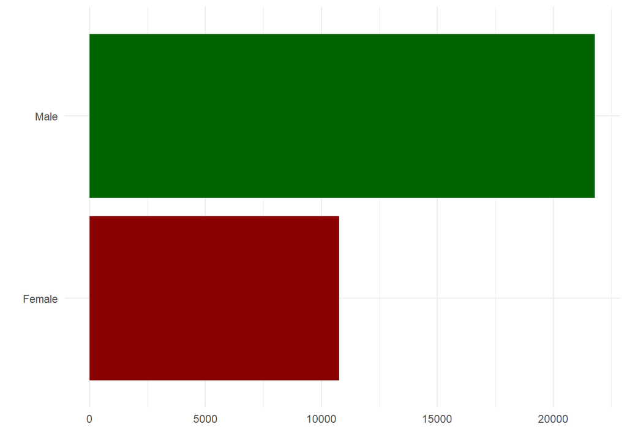

### Variable `race`

| Modalité | Nb de personnes | % du total |
| --- | --- | --- |
| Amer-Indian-Eskimo | 311 | 0.96 |
| Asian-Pac-Islander | 1039 | 3.19 |
| Black | 3124 | 9.59 |
| Other | 271 | 0.83 |
| White | 27816 | 85.43 |

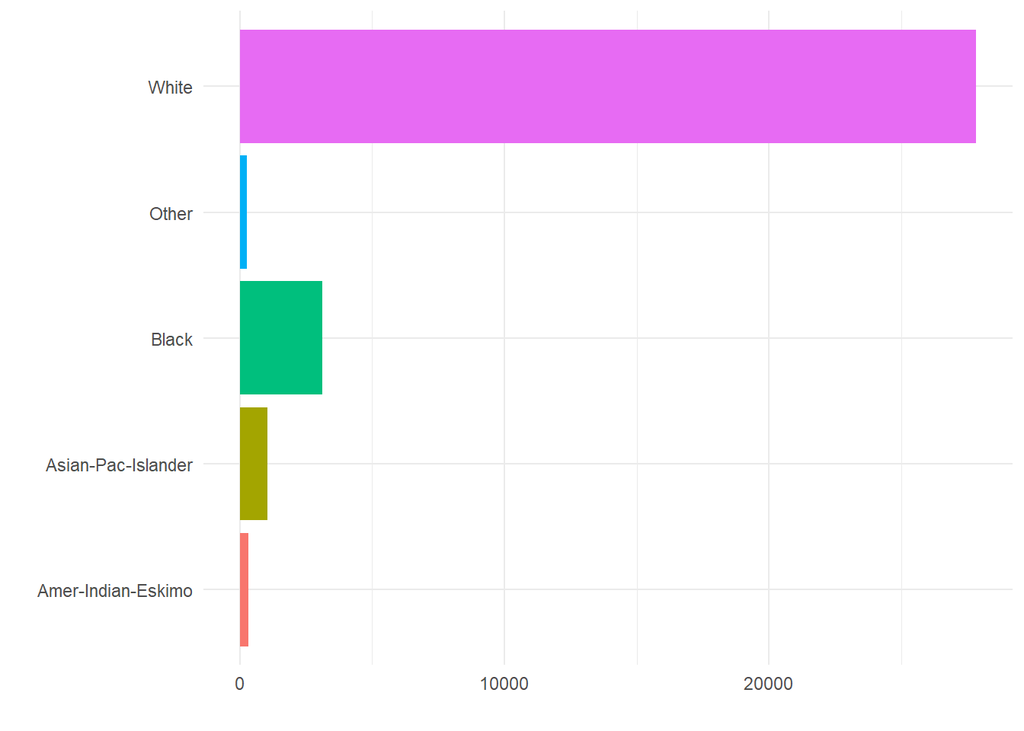

## Analyses bivariées

### Âge et salaire

L’âge étant quantitatif, et le salaire binaire (donc qualitatif à 2 modalités), on va chercher à tester les différences entre deux échantillons à l’aide du *t*-test (ou test de Student) et du test de Wilcoxon.

Les personnes gagnant plus de 50000$ sont plus âgées que les autres, ce qui semble assez logique. Les deux tests (resp. *t-test* et *Wilcoxon*) confirment la nette différence d’âge entre les deux classes de salaire (avec les *p-value* respectives suivantes : < 2.22e-16 et < 2.22e-16).

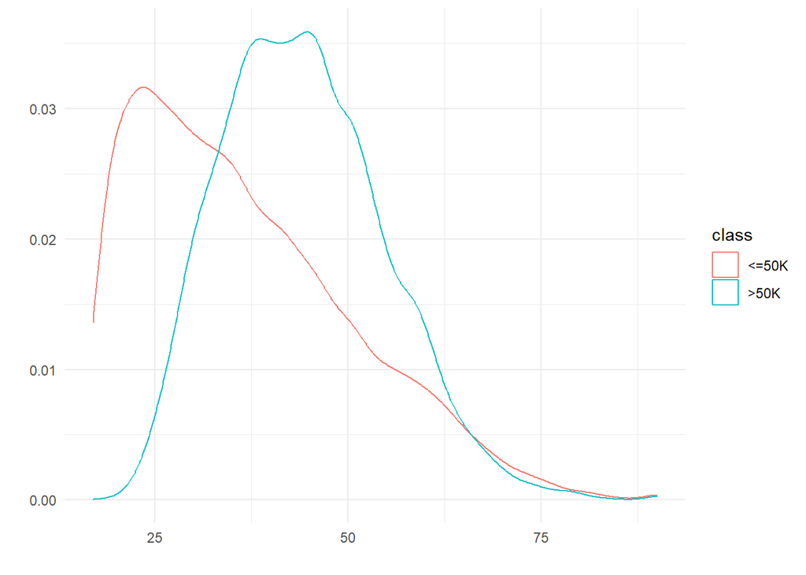

| class | Age |
| --- | --- |
| <=50K | 36.78 |
| >50K | 44.25 |

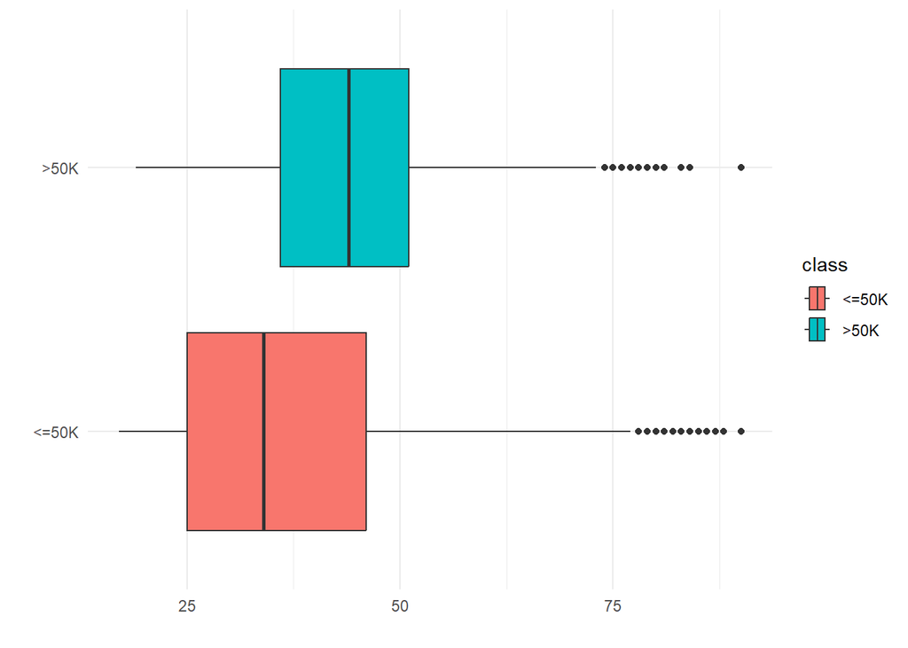

### Nombre d’heures de travail par semaine et salaire

On se retrouve dans le même cas que précédemment.

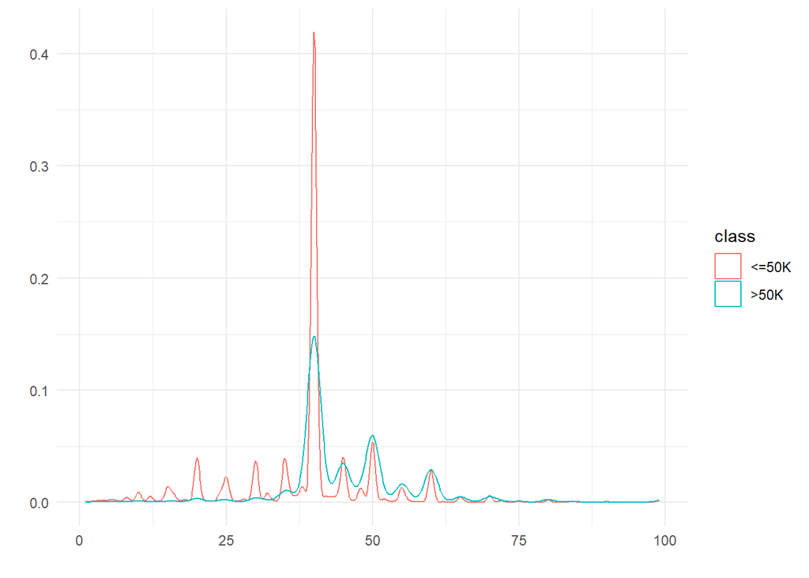

| class | Age |
| --- | --- |
| <=50K | 38.84 |
| >50K | 45.47 |

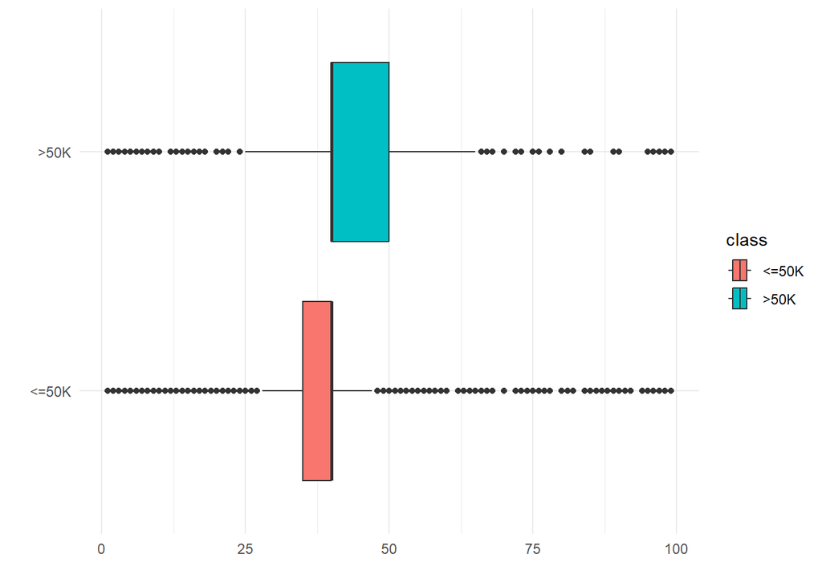

### Sexe et salaire

Les deux variables étant qualitatives (binaires), nous allons chercher le lien avec le test du $\chi^2$.

Sans surprise malheureusement, on remarque les femmes sont moins nombreuses à gagner plus de 50000$ par an. Ceci est confirmé par le test du $\chi^2$, avec une *p-value* de < 2.22e-16.

|  | <=50K | >50K |
| --- | --- | --- |
| Female | 38.8 | 15.04 |
| Male | 61.2 | 84.96 |

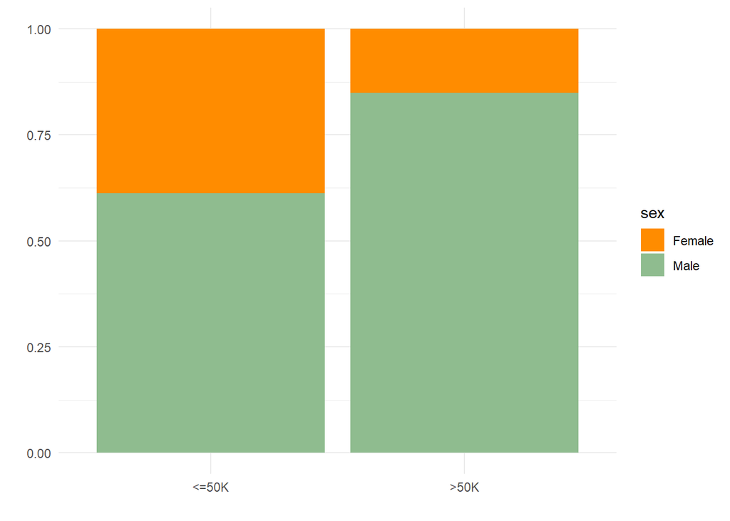

### Catégorie ethnique (variable `race`) et salaire

Même cas que précédemment.

Il y a bien un lien entre les deux variables. Ceci est confirmé par le test du $\chi^2$, avec une *p-value* de < 2.22e-16. Les personnes dites *blanches* ou de provenance asiatique/pacifique sont plus fréquemment payées plus de 50000$, contrairement aux autres ethnies.

|  | <=50K | >50K |
| --- | --- | --- |
| Amer-Indian-Eskimo | 88.42 | 11.58 |
| Asian-Pac-Islander | 73.44 | 26.56 |
| Black | 87.61 | 12.39 |
| Other | 90.77 | 9.23 |
| White | 74.41 | 25.59 |

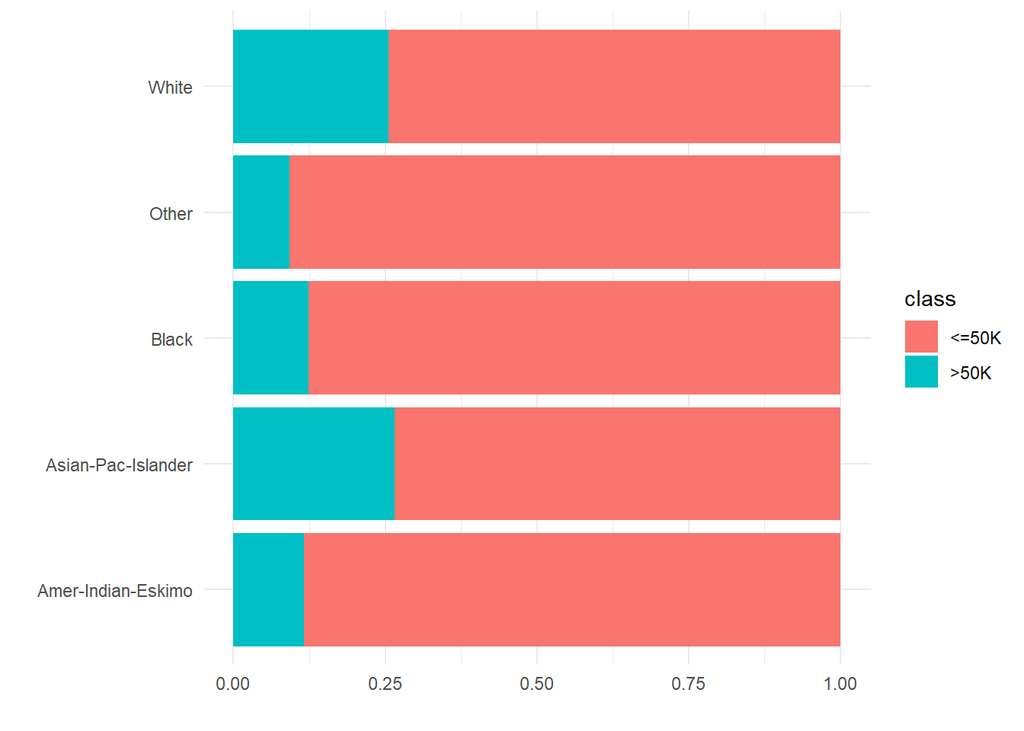

### Âge et nombre d’heures de travail par semaine

Nous avons ici deux variables quantitatives, nous allons donc faire un test de corrélation (avec les trois méthodes : *Pearson*, *Spearman* et *Kendall*).

Bien que les *p-values* indiquent qu’il y a un lien entre les deux variables, les estimations du coefficient de corrélation sont proches de 0. On peut difficilement établir un lien clair entre les deux.

Dans ce cas, il serait nécessaire de transformer la variable `hours_per_week` en une varaible binaire (“moins de 40h” vs “plus de 40h” par exemple).

| Méthode | Estimation du coefficien de corrélation | p-value |
| --- | --- | --- |
| Pearson | 0.0687557 | < 2.22e-16 |
| Spearman | 0.1429068 | < 2.22e-16 |
| Kendall | 0.1078910 | < 2.22e-16 |

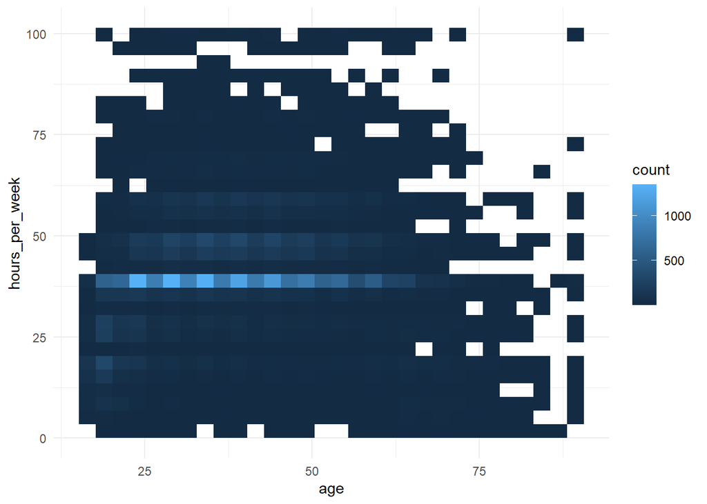

## Analyses multivariées

### Existe-t’il une partition ?

A l’aide d’une ACP et d’une classification sur les variables quantitatives, indiquer s’il y a une répartition en classes intéressantes

Ici, le nombre d’individus est trop important pour pouvoir réaliser une CAH directement. Nous allons donc déjà résumer les données en 100 classes via $k$-means.

Pour information, la partition en 100 classes explique tout de même 97% de l’information totale.

Sur la base du dendrogramme obtenu, on peut considérer que le choix de 4 classes est intéressant.

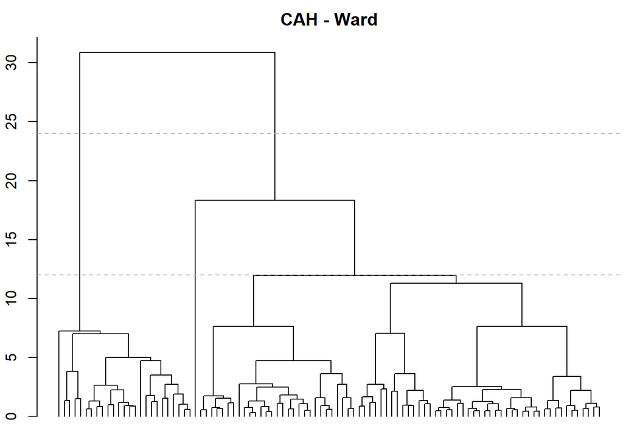

Avec une recherche du nombre de classes directement par $k$-means, en utilisant les critères $r^2$ et $PseudoF$, on a du mal à définir un nombre de classes de façon nette. Le premier critère semble ne pas proposé de choix (légère inflexion à 4 et 5 classes), et le deuxième propose lui 8 classes (il y a aussi une très légère inflexion à 4 classes).

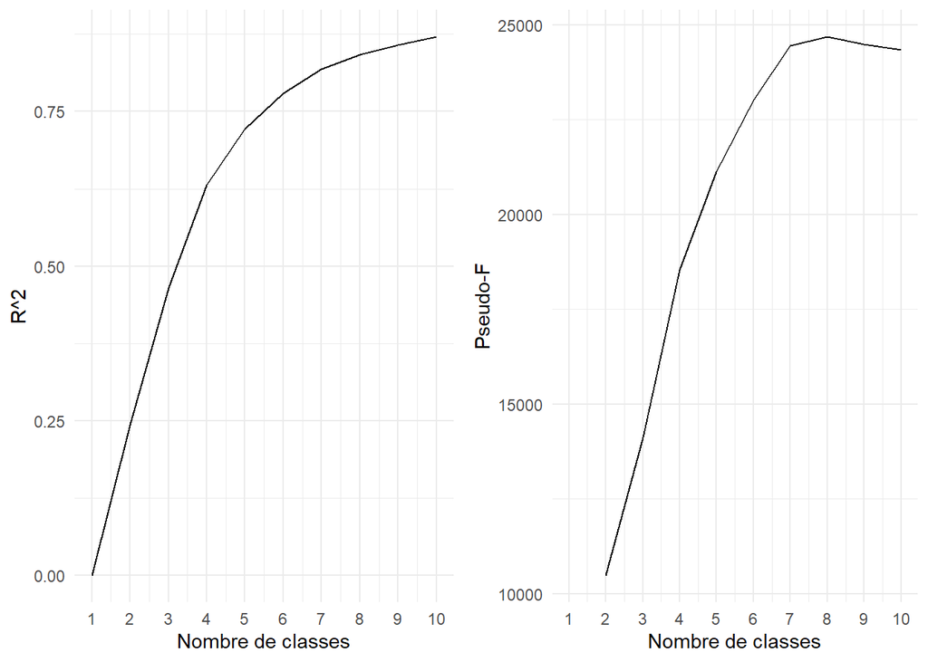

La représentation sur le premier plan factoriel est assez particulière, avec des classes très allongées. En regardant en plus le cercle de corrélations, les boîtes à moustaches de chaque variable par classe et les centres des classes, on remarque qu’on a une classe d’individus avec de forts gains sur leurs placements, âgées et travaillant beaucoup.

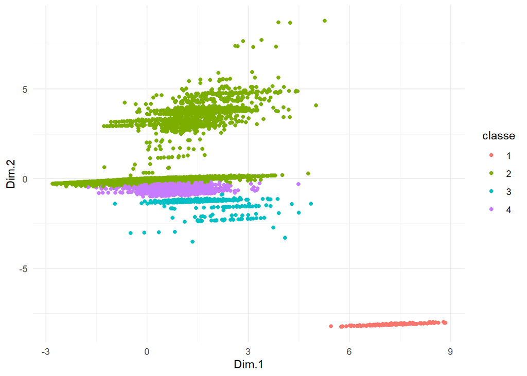

A noter que le premier plan factoriel représente 55% de l’information.

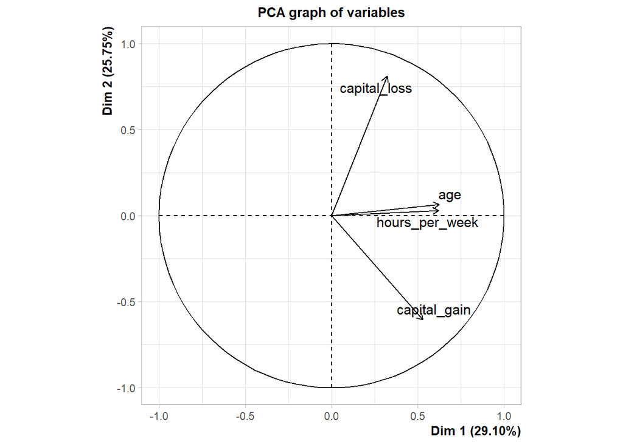

| classe | age | hours_per_week | capital_gain | capital_loss |
| --- | --- | --- | --- | --- |
| 1 | 46.35849056603774 | 49.79874213836478 | 99999 | 0 |
| 2 | 38.1541505887009 | 40.11615711882853 | 31.79512549058408 | 93.75350417202598 |
| 3 | 46.87454545454545 | 46.87636363636364 | 16547.70181818182 | 0 |
| 4 | 43.26126714565643 | 43.51534944480731 | 5959.625734813847 | 0 |

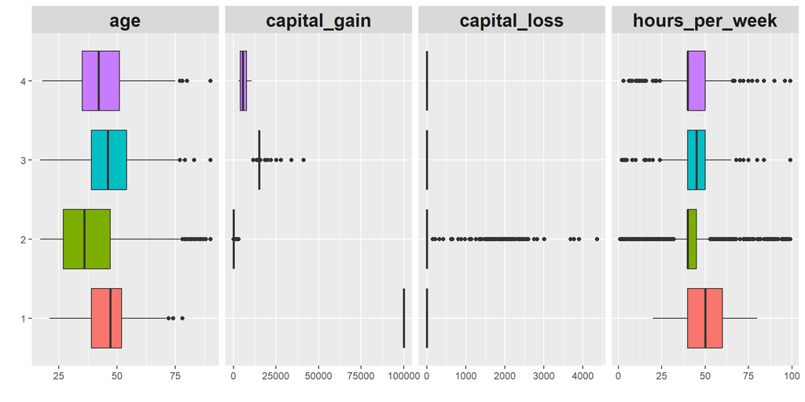

### Lien entre catégorie ethnique et statut marital

On calcule la table de contingence entre ces deux variables. On remarque que les statuts *Married-spouse-absent* et surtout *Married-AF-spouse* sont peu présents.

|  | Amer-Indian-Eskimo | Asian-Pac-Islander | Black | Other | White |
| --- | --- | --- | --- | --- | --- |
| Divorced | 60 | 75 | 485 | 26 | 3797 |
| Married-civ-spouse | 116 | 508 | 837 | 105 | 13410 |
| Married-spouse-absent | 9 | 41 | 62 | 15 | 291 |
| Never-married | 103 | 372 | 1346 | 105 | 8757 |
| Separated | 11 | 19 | 265 | 13 | 717 |
| Widowed | 12 | 24 | 128 | 7 | 822 |
| Married-AF-spouse | 0 | 0 | 1 | 0 | 22 |

On décide donc de les réunir avec l’autre statut *Married-civ-spouse* dans la suite de cette partie.

|  | Amer-Indian-Eskimo | Asian-Pac-Islander | Black | Other | White |
| --- | --- | --- | --- | --- | --- |
| Divorced | 60 | 75 | 485 | 26 | 3797 |
| Married | 125 | 549 | 900 | 120 | 13723 |
| Never-married | 103 | 372 | 1346 | 105 | 8757 |
| Separated | 11 | 19 | 265 | 13 | 717 |
| Widowed | 12 | 24 | 128 | 7 | 822 |

Grâce à l’AFC, on fait les remarques suivantes :

- La modalité *Black* est très proche de la modalité *Separated* ;
- La modalité *White* est placé au centre du nuage, proche de la modalité *Married* ;
- Les modalités *Asian-Pac-Islander* et *Other* sont opposées à la modalité *Amer-Indian-Eskimo*, celle-ci étant proche des modalités *Divorced* et *Widowed* dans une moindre mesure.

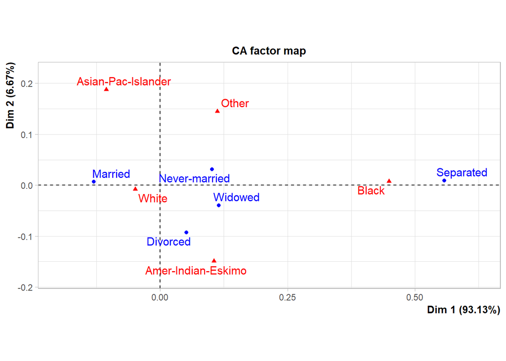

Le graphique ci-dessous confirme nos analyses précédentes.

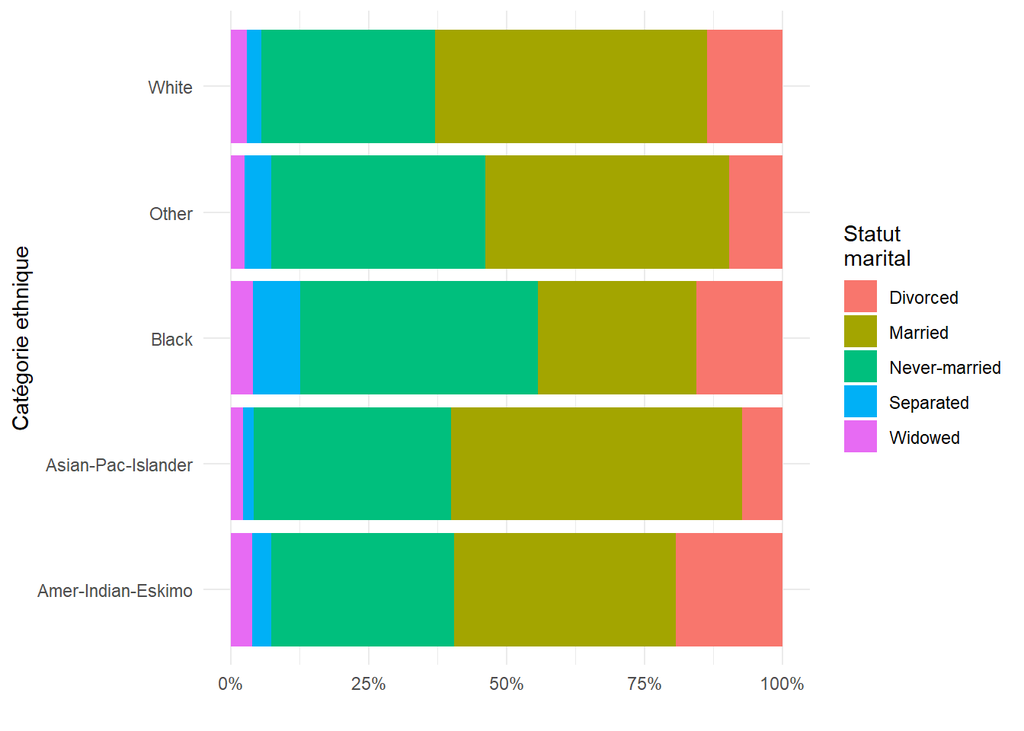